# cola Report for Consensus Partitioning

**Date**: 2022-07-11 16:30:13 CEST, **cola version**: 2.2.0

[figure not shown]

## Summary

First the variable is renamed to `res_list`.

```r
res_list = npm1.all_consensus_partition_k4.out
```

All available functions which can be applied to this `res_list` object:

```r
res_list
```

```
#> A 'ConsensusPartitionList' object with 24 methods.
#>   On a matrix with 5223 rows and 86 columns.
#>   Top rows are extracted by 'SD, CV, MAD, ATC' methods.
#>   Subgroups are detected by 'hclust, kmeans, skmeans, pam, mclust, NMF' method.
#>   Number of partitions are tried for k = 2, 3, 4.
#>   Performed in total 3600 partitions by row resampling.
#>
#> Following methods can be applied to this 'ConsensusPartitionList' object:
#>  [1] "cola_report"           "collect_classes"       "collect_plots"         "collect_stats"
#>  [5] "colnames"              "functional_enrichment" "get_anno"              "get_anno_col"
#>  [9] "get_classes"           "get_matrix"            "get_membership"        "get_stats"
#> [13] "is_best_k"             "is_stable_k"           "ncol"                  "nrow"
#> [17] "rownames"              "show"                  "suggest_best_k"        "test_to_known_factors"
#> [21] "top_rows_heatmap"      "top_rows_overlap"
#>
#> You can get result for a single method by, e.g. object["SD", "hclust"] or object["SD:hclust"]
#> or a subset of methods by object[c("SD", "CV")], c("hclust", "kmeans")]
```

The call of `run_all_consensus_partition_methods()` was:

```
#> run_all_consensus_partition_methods(data = prot_npm1, top_value_method = all_top_value_methods(),
#>     partition_method = all_partition_methods(), max_k = 4, cores = parallel::detectCores() -
#>         1, anno = npm1_phen[colnames(prot_npm1), ], verbose = T)
```

Dimension of the input matrix:

```r
mat = get_matrix(res_list)
dim(mat)
```

```
#> [1] 5223   86
```

### Density distribution

The density distribution for each sample is visualized as in one column in the following heatmap. The clustering is based on the distance which is the Kolmogorov-Smirnov statistic between two distributions.

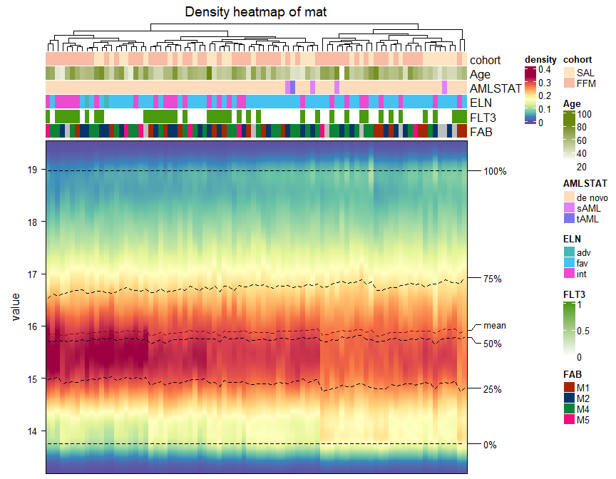

```r
library(ComplexHeatmap)
densityHeatmap(mat, top_annotation = HeatmapAnnotation(df = get_anno(res_list),
    col = get_anno_col(res_list)), ylab = "value", cluster_columns = TRUE, show_column_names = FALSE,
    mc.cores = 1)
```

### Suggest the best k

[The cola vignette](https://jokergoo.github.io/cola_vignettes/cola.html#toc_13) explains the definition of the metrics used for determining the best number of partitions.

```r
suggest_best_k(res_list)
```

|  | The best k | 1-PAC | Mean silhouette | Concordance |  | Optional k |
| --- | --- | --- | --- | --- | --- | --- |
| SD:kmeans | 2 | 1.000 | 0.986 | 0.994 | ** |  |
| CV:kmeans | 2 | 1.000 | 0.986 | 0.993 | ** |  |
| CV:mclust | 2 | 1.000 | 0.979 | 0.991 | ** |  |
| MAD:kmeans | 2 | 1.000 | 0.960 | 0.985 | ** |  |
| MAD:skmeans | 3 | 1.000 | 0.973 | 0.990 | ** | 2 |
| MAD:mclust | 2 | 1.000 | 0.975 | 0.989 | ** |  |
| ATC:kmeans | 3 | 1.000 | 0.977 | 0.991 | ** |  |
| ATC:pam | 3 | 1.000 | 0.986 | 0.994 | ** |  |
| ATC:mclust | 2 | 1.000 | 0.968 | 0.984 | ** |  |
| ATC:skmeans | 3 | 0.987 | 0.939 | 0.974 | ** | 2 |
| SD:skmeans | 3 | 0.958 | 0.968 | 0.984 | ** | 2 |
| MAD:NMF | 2 | 0.951 | 0.939 | 0.976 | ** |  |
| CV:skmeans | 3 | 0.942 | 0.910 | 0.963 | * | 2 |
| ATC:NMF | 2 | 0.927 | 0.909 | 0.963 | * |  |
| MAD:pam | 2 | 0.925 | 0.940 | 0.975 | * |  |
| SD:NMF | 3 | 0.917 | 0.917 | 0.964 | * | 2 |
| CV:NMF | 3 | 0.903 | 0.903 | 0.959 | * | 2 |
| MAD:hclust | 2 | 0.785 | 0.863 | 0.944 |  |  |
| CV:pam | 2 | 0.769 | 0.921 | 0.956 |  |  |
| ATC:hclust | 3 | 0.725 | 0.820 | 0.920 |  |  |
| SD:mclust | 2 | 0.723 | 0.919 | 0.960 |  |  |
| SD:pam | 2 | 0.577 | 0.884 | 0.942 |  |  |
| CV:hclust | 2 | 0.495 | 0.739 | 0.883 |  |  |
| SD:hclust | 2 | 0.491 | 0.825 | 0.915 |  |  |

**: 1-PAC > 0.95, *: 1-PAC > 0.9

### CDF of consensus matrices

```r
collect_plots(res_list, fun = plot_ecdf)
```

[output not shown]

### Consensus heatmap

- k = 2
- k = 3
- k = 4

```r
collect_plots(res_list, k = 2, fun = consensus_heatmap, cores = 1)
```

[output not shown]

```r
collect_plots(res_list, k = 3, fun = consensus_heatmap, cores = 1)
```

[output not shown]

```r
collect_plots(res_list, k = 4, fun = consensus_heatmap, cores = 1)
```

[output not shown]

### Membership heatmap

- k = 2
- k = 3
- k = 4

```r
collect_plots(res_list, k = 2, fun = membership_heatmap, cores = 1)
```

[output not shown]

```r
collect_plots(res_list, k = 3, fun = membership_heatmap, cores = 1)
```

[output not shown]

```r
collect_plots(res_list, k = 4, fun = membership_heatmap, cores = 1)
```

[output not shown]

### Signature heatmap

- k = 2
- k = 3
- k = 4

```r
collect_plots(res_list, k = 2, fun = get_signatures, cores = 1)
```

[output not shown]

```r
collect_plots(res_list, k = 3, fun = get_signatures, cores = 1)
```

[output not shown]

```r
collect_plots(res_list, k = 4, fun = get_signatures, cores = 1)
```

[output not shown]

### Statistics table

The statistics used for measuring the stability of consensus partitioning. ([How are they defined?](https://jokergoo.github.io/cola_vignettes/cola.html#toc_13))

- k = 2
- k = 3
- k = 4

```r
get_stats(res_list, k = 2)
```

```
#>             k 1-PAC mean_silhouette concordance area_increased  Rand Jaccard
#> SD:NMF      2 0.975           0.949       0.979          0.505 0.494   0.494
#> CV:NMF      2 0.951           0.949       0.979          0.505 0.495   0.495
#> MAD:NMF     2 0.951           0.939       0.976          0.505 0.494   0.494
#> ATC:NMF     2 0.927           0.909       0.963          0.500 0.494   0.494
#> SD:skmeans  2 1.000           0.999       1.000          0.506 0.494   0.494
#> CV:skmeans  2 1.000           0.998       0.999          0.506 0.494   0.494
#> MAD:skmeans 2 1.000           0.993       0.997          0.506 0.494   0.494
#> ATC:skmeans 2 1.000           0.982       0.992          0.505 0.494   0.494
#> SD:mclust   2 0.723           0.919       0.960          0.451 0.556   0.556
#> CV:mclust   2 1.000           0.979       0.991          0.440 0.556   0.556
#> MAD:mclust  2 1.000           0.975       0.989          0.497 0.504   0.504
#> ATC:mclust  2 1.000           0.968       0.984          0.348 0.652   0.652
#> SD:kmeans   2 1.000           0.986       0.994          0.505 0.494   0.494
#> CV:kmeans   2 1.000           0.986       0.993          0.505 0.494   0.494
#> MAD:kmeans  2 1.000           0.960       0.985          0.504 0.497   0.497
#> ATC:kmeans  2 0.885           0.951       0.980          0.491 0.508   0.508
#> SD:pam      2 0.577           0.884       0.942          0.488 0.508   0.508
#> CV:pam      2 0.769           0.921       0.956          0.491 0.508   0.508
#> MAD:pam     2 0.925           0.940       0.975          0.502 0.498   0.498
#> ATC:pam     2 0.581           0.926       0.951          0.437 0.564   0.564
#> SD:hclust   2 0.491           0.825       0.915          0.490 0.494   0.494
#> CV:hclust   2 0.495           0.739       0.883          0.469 0.504   0.504
#> MAD:hclust  2 0.785           0.863       0.944          0.501 0.494   0.494
#> ATC:hclust  2 0.469           0.804       0.852          0.330 0.709   0.709
```

```r
get_stats(res_list, k = 3)
```

```
#>             k 1-PAC mean_silhouette concordance area_increased  Rand Jaccard
#> SD:NMF      3 0.917           0.917       0.964          0.325 0.732   0.509
#> CV:NMF      3 0.903           0.903       0.959          0.321 0.732   0.510
#> MAD:NMF     3 0.824           0.858       0.942          0.317 0.769   0.564
#> ATC:NMF     3 0.694           0.821       0.909          0.318 0.732   0.513
#> SD:skmeans  3 0.958           0.968       0.984          0.279 0.843   0.689
#> CV:skmeans  3 0.942           0.910       0.963          0.292 0.801   0.615
#> MAD:skmeans 3 1.000           0.973       0.990          0.279 0.828   0.663
#> ATC:skmeans 3 0.987           0.939       0.974          0.251 0.851   0.706
#> SD:mclust   3 0.544           0.716       0.864          0.226 0.893   0.810
#> CV:mclust   3 0.726           0.757       0.837          0.204 0.840   0.712
#> MAD:mclust  3 0.631           0.835       0.911          0.151 0.929   0.861
#> ATC:mclust  3 0.825           0.867       0.944          0.898 0.652   0.478
#> SD:kmeans   3 0.675           0.853       0.900          0.300 0.746   0.529
#> CV:kmeans   3 0.731           0.862       0.917          0.301 0.770   0.566
#> MAD:kmeans  3 0.661           0.834       0.876          0.292 0.796   0.607
#> ATC:kmeans  3 1.000           0.977       0.991          0.234 0.742   0.554
#> SD:pam      3 0.491           0.656       0.839          0.365 0.690   0.458
#> CV:pam      3 0.580           0.810       0.889          0.360 0.710   0.484
#> MAD:pam     3 0.690           0.799       0.909          0.329 0.731   0.508
#> ATC:pam     3 1.000           0.986       0.994          0.502 0.666   0.463
#> SD:hclust   3 0.482           0.573       0.816          0.213 0.948   0.895
#> CV:hclust   3 0.495           0.588       0.827          0.242 0.886   0.786
#> MAD:hclust  3 0.620           0.731       0.865          0.175 0.938   0.874
#> ATC:hclust  3 0.725           0.820       0.920          0.751 0.644   0.514
```

```r
get_stats(res_list, k = 4)
```

```
#>             k 1-PAC mean_silhouette concordance area_increased  Rand Jaccard
#> SD:NMF      4 0.698           0.687       0.841         0.1059 0.869   0.638
#> CV:NMF      4 0.683           0.678       0.850         0.1159 0.865   0.631
#> MAD:NMF     4 0.651           0.644       0.829         0.1138 0.853   0.605
#> ATC:NMF     4 0.660           0.681       0.847         0.0880 0.899   0.721
#> SD:skmeans  4 0.746           0.795       0.889         0.1341 0.910   0.750
#> CV:skmeans  4 0.750           0.802       0.891         0.1176 0.910   0.743
#> MAD:skmeans 4 0.747           0.681       0.846         0.1055 0.974   0.926
#> ATC:skmeans 4 0.828           0.794       0.896         0.0925 0.920   0.795
#> SD:mclust   4 0.727           0.871       0.909         0.0424 0.876   0.761
#> CV:mclust   4 0.735           0.871       0.923         0.0744 0.816   0.639
#> MAD:mclust  4 0.563           0.778       0.845         0.1220 0.867   0.713
#> ATC:mclust  4 0.593           0.776       0.848         0.0482 0.896   0.707
#> SD:kmeans   4 0.674           0.680       0.753         0.1234 0.902   0.713
#> CV:kmeans   4 0.676           0.672       0.768         0.1158 0.932   0.802
#> MAD:kmeans  4 0.635           0.616       0.724         0.1271 0.898   0.710
#> ATC:kmeans  4 0.619           0.500       0.664         0.1736 0.895   0.746
#> SD:pam      4 0.496           0.656       0.767         0.1048 0.850   0.593
#> CV:pam      4 0.533           0.657       0.801         0.0940 0.915   0.752
#> MAD:pam     4 0.624           0.659       0.818         0.1068 0.894   0.690
#> ATC:pam     4 0.799           0.893       0.919         0.1303 0.804   0.502
#> SD:hclust   4 0.476           0.517       0.779         0.0950 0.977   0.948
#> CV:hclust   4 0.467           0.560       0.794         0.1119 0.932   0.849
#> MAD:hclust  4 0.611           0.700       0.822         0.1268 0.902   0.772
#> ATC:hclust  4 0.624           0.764       0.853         0.1472 0.941   0.858
```

- k = 2
- k = 3
- k = 4

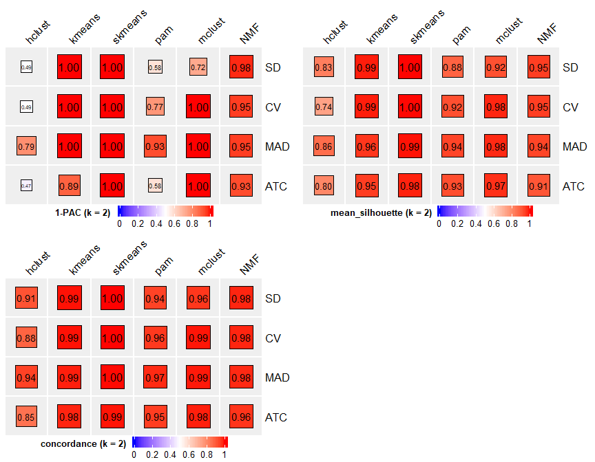

```r
collect_stats(res_list, k = 2)
```

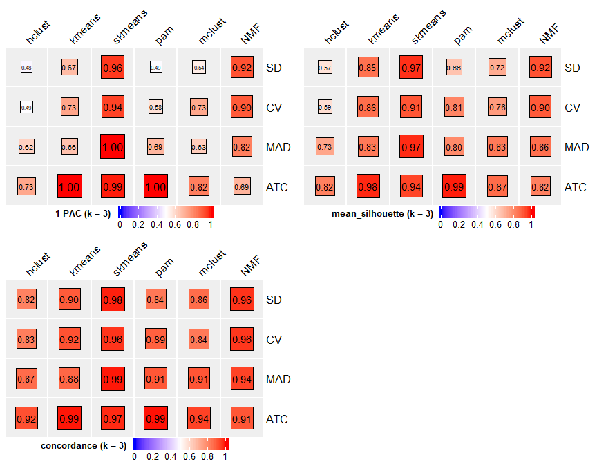

```r
collect_stats(res_list, k = 3)
```

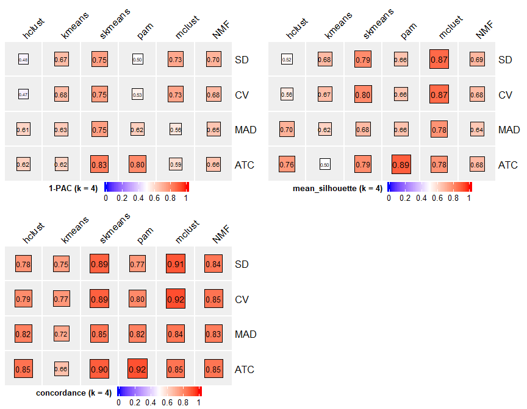

```r
collect_stats(res_list, k = 4)
```

### Partition from all methods

Collect partitions from all methods:

- k = 2
- k = 3
- k = 4

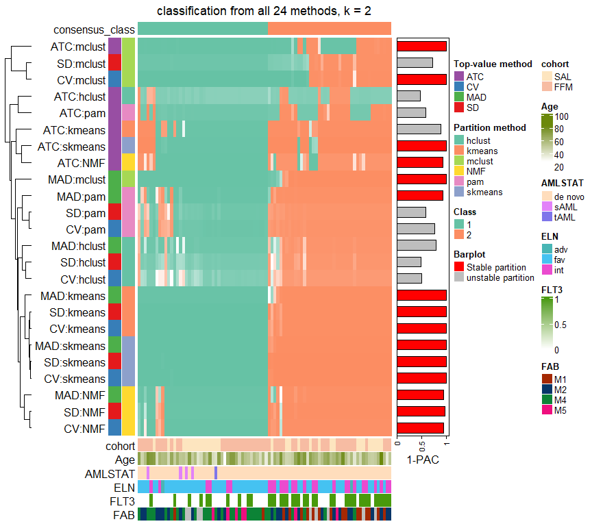

```r
collect_classes(res_list, k = 2)
```

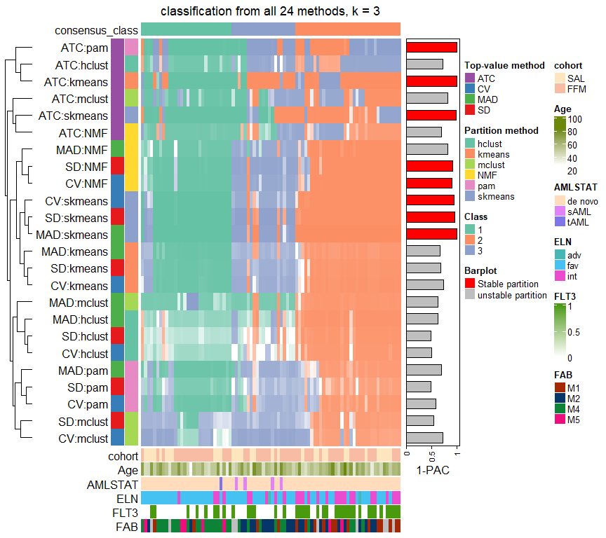

```r
collect_classes(res_list, k = 3)
```

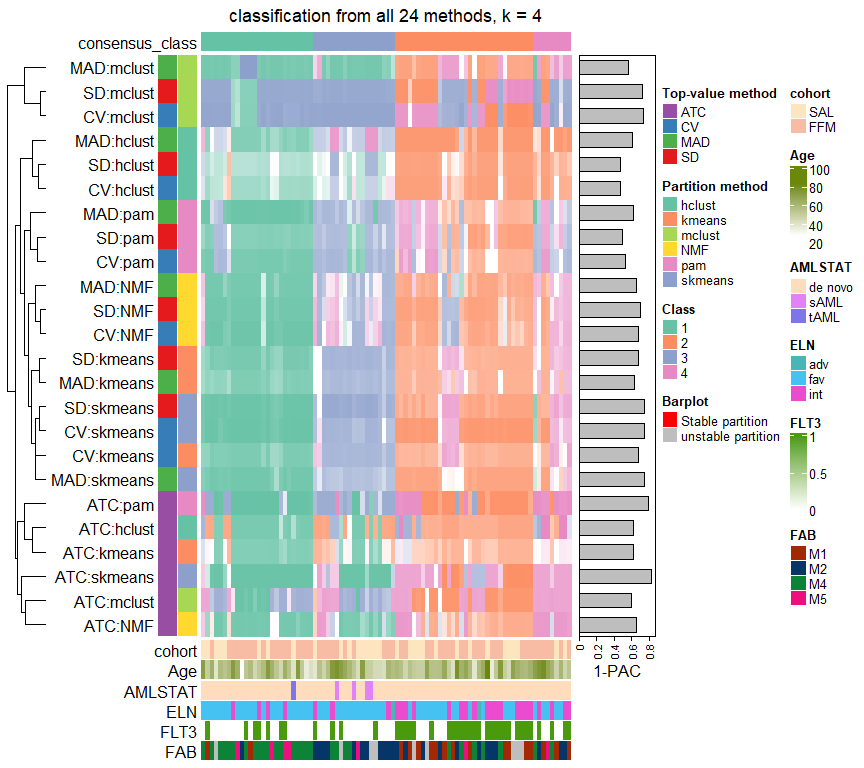

```r
collect_classes(res_list, k = 4)
```

### Top rows overlap

Overlap of top rows from different top-row methods:

- top_n = 522

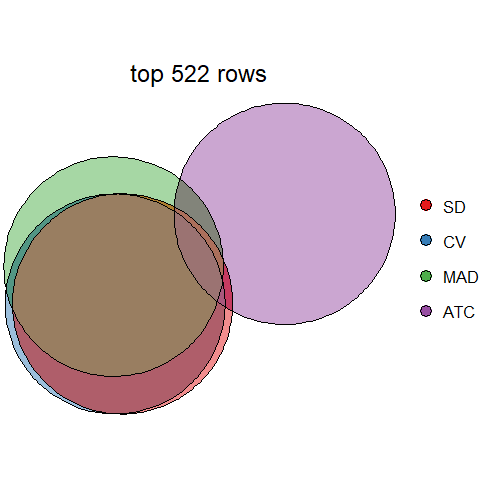

```r
top_rows_overlap(res_list, top_n = 522, method = "euler")
```

Also visualize the correspondance of rankings between different top-row methods:

- top_n = 522

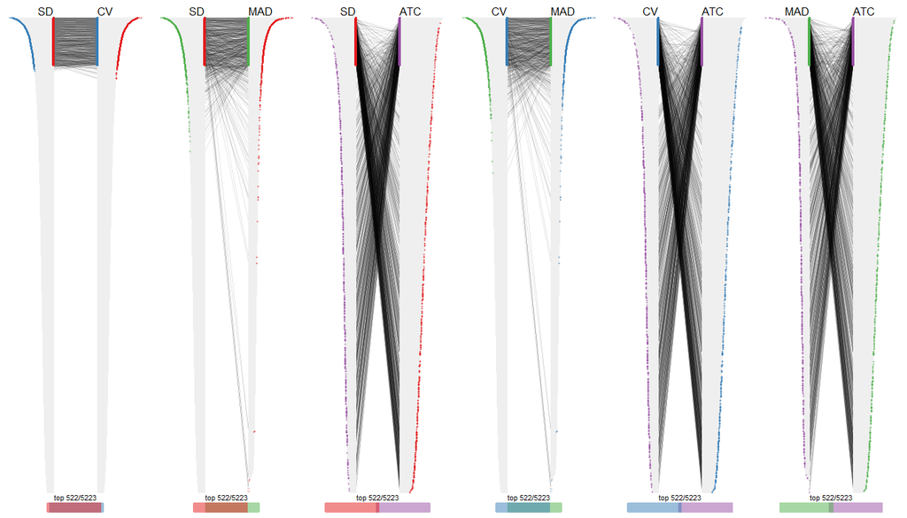

```r
top_rows_overlap(res_list, top_n = 522, method = "correspondance")
```

Heatmaps of the top rows:

- top_n = 522

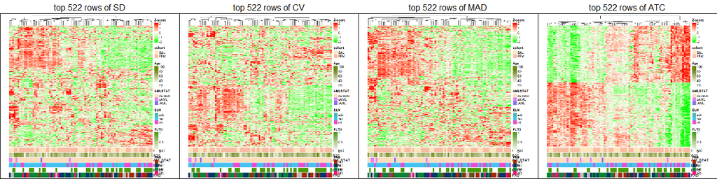

```r
top_rows_heatmap(res_list, top_n = 522)
```

### Test to known annotations

Following tests correlation between subgroups and known annotations. If the known annotation is numeric, one-way ANOVA test is applied, and if the known annotation is discrete, chi-squared contingency table test is applied.

- k = 2
- k = 3
- k = 4

```r
test_to_known_factors(res_list, k = 2)
```

```
#>             n_sample cohort(p-value) Age(p-value) AMLSTAT(p-value) ELN(p-value) FLT3(p-value)
#> SD:NMF            84           0.906       0.6984           0.0537     0.000503      2.52e-04
#> CV:NMF            84           0.906       0.6984           0.0537     0.000503      2.52e-04
#> MAD:NMF           83           1.000       0.5925           0.0842     0.003486      2.22e-04
#> ATC:NMF           80           0.862       0.3254           0.4318     0.091627      8.58e-03
#> SD:skmeans        86           1.000       0.4544           0.0794     0.001253      6.90e-06
#> CV:skmeans        86           1.000       0.4544           0.0794     0.001253      6.90e-06
#> MAD:skmeans       86           1.000       0.4544           0.0794     0.001253      6.90e-06
#> ATC:skmeans       86           0.697       0.3170           0.3225     0.015452      1.93e-03
#> SD:mclust         86           0.607       0.7002           0.2776     0.220259      1.53e-02
#> CV:mclust         85           0.521       0.5047           0.2904     0.298049      2.30e-02
#> MAD:mclust        85           0.797       0.4529           0.1291     0.023554      1.51e-04
#> ATC:mclust        85           0.105       0.8272           0.4899     0.356511      1.66e-03
#> SD:kmeans         86           1.000       0.4544           0.0794     0.001253      6.90e-06
#> CV:kmeans         86           1.000       0.4544           0.0794     0.001253      6.90e-06
#> MAD:kmeans        84           1.000       0.3183           0.0999     0.008522      6.75e-05
#> ATC:kmeans        84           0.868       0.1085           0.1608     0.006129      2.90e-04
#> SD:pam            83           0.629       0.1942           0.0644     0.001788      1.68e-03
#> CV:pam            86           0.617       0.1512           0.1847     0.003775      4.54e-03
#> MAD:pam           84           0.772       0.4958           0.0466     0.002280      1.47e-03
#> ATC:pam           85           1.000       0.1876           0.7726     0.125772      1.56e-01
#> SD:hclust         83           1.000       0.2929           0.0842     0.007256      8.19e-05
#> CV:hclust         75           1.000       0.3769           0.0783     0.007157      1.34e-03
#> MAD:hclust        81           1.000       0.2124           0.0743     0.023571      4.22e-04
#> ATC:hclust        86           0.962       0.0382           0.8305     0.327654      5.15e-01
#>             FAB(p-value) k
#> SD:NMF          1.12e-05 2
#> CV:NMF          1.12e-05 2
#> MAD:NMF         1.77e-05 2
#> ATC:NMF         2.32e-03 2
#> SD:skmeans      7.26e-05 2
#> CV:skmeans      7.26e-05 2
#> MAD:skmeans     7.26e-05 2
#> ATC:skmeans     6.06e-03 2
#> SD:mclust       3.26e-04 2
#> CV:mclust       1.09e-04 2
#> MAD:mclust      1.39e-05 2
#> ATC:mclust      3.24e-05 2
#> SD:kmeans       7.26e-05 2
#> CV:kmeans       7.26e-05 2
#> MAD:kmeans      2.14e-05 2
#> ATC:kmeans      5.92e-04 2
#> SD:pam          1.71e-04 2
#> CV:pam          3.73e-04 2
#> MAD:pam         4.56e-06 2
#> ATC:pam         1.28e-01 2
#> SD:hclust       2.21e-04 2
#> CV:hclust       7.35e-04 2
#> MAD:hclust      4.42e-04 2
#> ATC:hclust      6.12e-01 2
```

```r
test_to_known_factors(res_list, k = 3)
```

```
#>             n_sample cohort(p-value) Age(p-value) AMLSTAT(p-value) ELN(p-value) FLT3(p-value)
#> SD:NMF            84          0.9873       0.4280         1.44e-02      0.03240      4.46e-03
#> CV:NMF            81          0.9831       0.4514         7.81e-03      0.02341      3.51e-03
#> MAD:NMF           79          0.7935       0.6328         4.59e-03      0.10974      8.21e-03
#> ATC:NMF           81          0.8751       0.0912         4.49e-01      0.10166      2.40e-02
#> SD:skmeans        86          0.4713       0.5303         2.01e-03      0.00857      1.09e-04
#> CV:skmeans        80          0.6706       0.5149         1.55e-03      0.01369      4.37e-05
#> MAD:skmeans       85          0.4688       0.5575         2.25e-03      0.01254      1.64e-04
#> ATC:skmeans       84          0.4706       0.2260         5.30e-01      0.04416      1.20e-03
#> SD:mclust         74          0.1332       0.7987         1.66e-01      0.27132      2.62e-02
#> CV:mclust         77          0.1095       0.7378         2.23e-01      0.45637      7.50e-02
#> MAD:mclust        80          0.2779       0.2903         2.30e-01      0.01472      6.64e-03
#> ATC:mclust        80          0.0935       0.1844         5.05e-01      0.02058      1.94e-04
#> SD:kmeans         83          0.6207       0.5245         1.83e-02      0.04691      1.21e-03
#> CV:kmeans         82          0.6535       0.5912         1.19e-02      0.03867      6.31e-04
#> MAD:kmeans        85          0.6726       0.5230         9.00e-03      0.10253      2.49e-03
#> ATC:kmeans        86          0.8713       0.0841         5.25e-01      0.06004      6.25e-02
#> SD:pam            73          0.8149       0.9045         9.64e-02      0.11626      5.27e-04
#> CV:pam            83          0.5471       0.3602         2.31e-01      0.11156      4.11e-04
#> MAD:pam           78          0.7807       0.4835         2.82e-02      0.08640      4.44e-03
#> ATC:pam           86          0.4446       0.0895         6.11e-01      0.04382      5.71e-02
#> SD:hclust         44          0.3570       0.6125         9.05e-04      0.67897      6.46e-01
#> CV:hclust         61          0.1978       0.6110         2.45e-04      0.00727           NaN
#> MAD:hclust        76          0.3640       0.3736         1.21e-05      0.12045      1.50e-02
#> ATC:hclust        81          0.9542       0.3941         3.96e-01      0.09814      1.80e-02
#>             FAB(p-value) k
#> SD:NMF          3.83e-05 3
#> CV:NMF          2.70e-05 3
#> MAD:NMF         7.88e-07 3
#> ATC:NMF         9.13e-03 3
#> SD:skmeans      2.45e-07 3
#> CV:skmeans      1.70e-06 3
#> MAD:skmeans     1.28e-07 3
#> ATC:skmeans     2.30e-03 3
#> SD:mclust       1.16e-02 3
#> CV:mclust       5.53e-03 3
#> MAD:mclust      6.80e-04 3
#> ATC:mclust      7.87e-04 3
#> SD:kmeans       1.10e-05 3
#> CV:kmeans       2.55e-05 3
#> MAD:kmeans      3.30e-07 3
#> ATC:kmeans      5.49e-03 3
#> SD:pam          6.24e-06 3
#> CV:pam          1.04e-04 3
#> MAD:pam         6.81e-06 3
#> ATC:pam         1.88e-03 3
#> SD:hclust       5.35e-01 3
#> CV:hclust       4.51e-05 3
#> MAD:hclust      2.72e-03 3
#> ATC:hclust      2.60e-03 3
```

```r
test_to_known_factors(res_list, k = 4)
```

```
#>             n_sample cohort(p-value) Age(p-value) AMLSTAT(p-value) ELN(p-value) FLT3(p-value)
#> SD:NMF            68           0.778     0.688733         2.04e-01     0.050164      0.013350
#> CV:NMF            67           0.799     0.678998         3.92e-01     0.098535      0.027367
#> MAD:NMF           66           0.662     0.365176         7.42e-02     0.032558           NaN
#> ATC:NMF           67           0.512     0.272081         3.57e-01     0.056693      0.000245
#> SD:skmeans        84           0.565     0.635360         7.78e-03     0.023507      0.000703
#> CV:skmeans        82           0.493     0.651588         6.11e-03     0.022898      0.000757
#> MAD:skmeans       73           0.423     0.510021         1.57e-02     0.050557      0.001551
#> ATC:skmeans       74           0.325     0.498481         5.81e-01     0.000713      0.004704
#> SD:mclust         83           0.278     0.792598         8.27e-01     0.171972      0.007293
#> CV:mclust         83           0.278     0.792598         8.27e-01     0.171972      0.007293
#> MAD:mclust        80           0.215     0.384371         4.69e-01     0.020501      0.007528
#> ATC:mclust        80           0.165     0.241267         5.01e-01     0.026480      0.000845
#> SD:kmeans         78           0.495     0.690064         5.60e-03     0.033009      0.000897
#> CV:kmeans         78           0.637     0.720540         9.08e-03     0.038771      0.001157
#> MAD:kmeans        75           0.743     0.813478         1.26e-02     0.021435      0.008123
#> ATC:kmeans        50           0.803     0.260679         2.85e-01     0.007610      0.004898
#> SD:pam            74           0.760     0.611594         1.58e-01     0.321535      0.004029
#> CV:pam            72           0.687     0.630697         2.60e-01     0.345124      0.002212
#> MAD:pam           72           0.881     0.723660         9.41e-02     0.263654      0.013195
#> ATC:pam           83           0.902     0.166510         5.39e-01     0.096030      0.002033
#> SD:hclust         47           0.680     0.205639         2.87e-06     0.537863      0.507059
#> CV:hclust         55           0.407     0.000098         8.22e-06     0.250747      0.299883
#> MAD:hclust        71           0.161     0.617144         7.38e-05     0.232478      0.007618
#> ATC:hclust        82           0.838     0.215730         6.41e-01     0.348029      0.097833
#>             FAB(p-value) k
#> SD:NMF          7.77e-04 4
#> CV:NMF          4.67e-05 4
#> MAD:NMF         2.79e-05 4
#> ATC:NMF         1.83e-03 4
#> SD:skmeans      6.53e-06 4
#> CV:skmeans      1.16e-05 4
#> MAD:skmeans     8.84e-06 4
#> ATC:skmeans     9.14e-05 4
#> SD:mclust       1.21e-02 4
#> CV:mclust       1.21e-02 4
#> MAD:mclust      1.12e-03 4
#> ATC:mclust      1.86e-03 4
#> SD:kmeans       3.37e-05 4
#> CV:kmeans       6.03e-06 4
#> MAD:kmeans      6.46e-06 4
#> ATC:kmeans      5.36e-03 4
#> SD:pam          1.34e-05 4
#> CV:pam          6.27e-06 4
#> MAD:pam         1.45e-07 4
#> ATC:pam         5.97e-04 4
#> SD:hclust       1.03e-02 4
#> CV:hclust       2.88e-03 4
#> MAD:hclust      7.65e-06 4
#> ATC:hclust      1.53e-02 4
```

[output not shown]

[output not shown]